# US Census Demographic Data

Data lovers

06 Dec 2021

### Chapter 1:Introduction.

Census is a very important matter, not just at the government level, but for individuals as well. The census population count decides how many congressional members each state will have for the following ten years, as well as how much federal funds localities will receive for roads, schools, housing, and social programs.

Poverty is a complicated issue. There are numerous elements to it, as well as numerous reasons. The most common definition of poverty focuses on financial hardship. This definition defines poverty rates for towns and countries based on income inequality and financially established poverty lines and quantifies poverty by the amount of money a person makes.

Poverty becomes relative in this way. In the United States, the poverty line for a family of four is little over $26,000 a year. That amount of money is more than 36 times what a family of four living in absolute poverty in a low-income country is forced to subsist on each year.

Many families in the world’s poorest countries must make do with less than $1.90 per day to cover their basic requirements. This sort of extreme poverty affects nearly 10% of the world’s population.

Understanding poverty solely in terms of economic disparity and calculating relative poverty thresholds makes it impossible to see poverty as anything other than unemployment, bad living conditions, and a low income. Poverty, on the other hand, is a much broader concept.

A fair definition of poverty must take into account the many various aspects of poverty, such as hunger and a lack of shelter, illiteracy and lack of access to education, being sick and unable to see a doctor, and fearing for one’s future.

By exploring this data and analyzing it we can come up with many insights, such as how the population varies across the states, which states that have the best transportation, how do income and poverty look like across US, employment/unemployment rates and so many questions that can be answered from these data.

Therefore, our aim in this project is to analyze the US census of 2015 to answer our interesting question:

1. Does a relationship exist between ‘child poverty’ and ‘unemployment’? Or how can we predict the unemployment rate?
2. Does the data support ‘professional’ (individual who has a professional job) influence ‘income’?
3. Does a relationship exist between ‘Professional’ and ‘Income’? How can we predict the average income in counties?

### Chapter 2:Description of the Data.

• Dataset that is used for our project is “US Census Demographic Data” taken from the common data source Kaggle (which is an online community of data scientists and machine learning practitioners.

Link: https://www.kaggle.com/muonneutrino/us-census-demographic-data?select=acs2015_county_data.csv

• Dataset contains information about (US Census 2015) American Community Survey 5-year estimates.

• Number of variables in the dataset is 37.

• Number of observations in the dataset is 3220.

• To perform Exploratory Data Analysis, we primarily focus on the following aspects(variables) from the dataset:

- TotalPop (Total population for county).
- Income. (Income in county).
- Poverty (Poverty rate in county).
- ChildPoverty. (Child poverty rate in county).
- Employed (Total employed for county).
- Unemployment. (Unemployment rate for county).
- Production. (Rate of this job sector in county).
- WorkAtHome. (Work-at-home rate in county).
- PublicWork. (Public work rate in county).
- SelfEmployed. (Self-employed rate in county).

**This is our dataset before performing any cleansing or dropping columns:**

```r
# importing the dataset as Adata, and making sure the data type for the variables are set properly for categorical variables.**

Adata1 <- data.frame(read.csv("acs2015_county_data.csv",header = TRUE))

str(Adata1)

#summary(Adata1)

#  we don't need to change any variables type, all of them set properly.
# There are a lot of variables , we may drop some of them, like :
#Hispanic, White,   Black,  Native, Asian   Pacific, IncomeErr, IncomePerCap,   IncomePerCapErr


# Dropping columns as agreed.

Adata <- data.frame (subset(Adata1, select = -c(Hispanic,White,Black, Native, Asian, Pacific,IncomeErr, IncomePerCap, IncomePerCapErr, Drive, Carpool, Transit, Walk, OtherTransp, MeanCommute)))

str(Adata)
#summary(Adata)
```

```
## 'data.frame':    3220 obs. of  37 variables:
##  $ CensusId       : int  1001 1003 1005 1007 1009 1011 1013 1015 1017 1019 ...
##  $ State          : chr  "Alabama" "Alabama" "Alabama" "Alabama" ...
##  $ County         : chr  "Autauga" "Baldwin" "Barbour" "Bibb" ...
##  $ TotalPop       : int  55221 195121 26932 22604 57710 10678 20354 116648 34079 26008 ...
##  $ Men            : int  26745 95314 14497 12073 28512 5660 9502 56274 16258 12975 ...
##  $ Women          : int  28476 99807 12435 10531 29198 5018 10852 60374 17821 13033 ...
##  $ Hispanic       : num  2.6 4.5 4.6 2.2 8.6 4.4 1.2 3.5 0.4 1.5 ...
##  $ White          : num  75.8 83.1 46.2 74.5 87.9 22.2 53.3 73 57.3 91.7 ...
##  $ Black          : num  18.5 9.5 46.7 21.4 1.5 70.7 43.8 20.3 40.3 4.8 ...
##  $ Native         : num  0.4 0.6 0.2 0.4 0.3 1.2 0.1 0.2 0.2 0.6 ...
##  $ Asian          : num  1 0.7 0.4 0.1 0.1 0.2 0.4 0.9 0.8 0.3 ...
##  $ Pacific        : num  0 0 0 0 0 0 0 0 0 0 ...
##  $ Citizen        : int  40725 147695 20714 17495 42345 8057 15581 88612 26462 20600 ...
##  $ Income         : num  51281 50254 32964 38678 45813 ...
```

[output cut: 46 more lines]

**And here is the summary of our dataset**

```r
summary(Adata)
```

```
##     CensusId        State              County             TotalPop
##  Min.   : 1001   Length:3220        Length:3220        Min.   :      85
##  1st Qu.:19032   Class :character   Class :character   1st Qu.:   11218
##  Median :30024   Mode  :character   Mode  :character   Median :   26035
##  Mean   :31394                                         Mean   :   99409
##  3rd Qu.:46106                                         3rd Qu.:   66430
##  Max.   :72153                                         Max.   :10038388
##
##       Men              Women            Citizen            Income
##  Min.   :     42   Min.   :     43   Min.   :     80   Min.   : 10499
##  1st Qu.:   5637   1st Qu.:   5572   1st Qu.:   8450   1st Qu.: 38192
##  Median :  12932   Median :  13057   Median :  19643   Median : 44749
##  Mean   :  48897   Mean   :  50512   Mean   :  69935   Mean   : 46130
##  3rd Qu.:  32993   3rd Qu.:  33488   3rd Qu.:  49920   3rd Qu.: 52074
##  Max.   :4945351   Max.   :5093037   Max.   :6046749   Max.   :123453
##                                                        NA's   :1
##     Poverty      ChildPoverty   Professional     Service         Office
##  Min.   : 1.4   Min.   : 0.0   Min.   :13.5   Min.   : 5.0   Min.   : 4.1
##  1st Qu.:12.1   1st Qu.:16.3   1st Qu.:26.7   1st Qu.:16.0   1st Qu.:20.2
##  Median :16.1   Median :22.7   Median :29.9   Median :18.1   Median :22.4
##  Mean   :17.5   Mean   :24.2   Mean   :31.0   Mean   :18.3   Mean   :22.2
##  3rd Qu.:20.7   3rd Qu.:30.0   3rd Qu.:34.4   3rd Qu.:20.3   3rd Qu.:24.4
##  Max.   :64.2   Max.   :81.6   Max.   :74.0   Max.   :38.2   Max.   :35.4
##                 NA's   :1
##   Construction    Production     WorkAtHome      Employed        PrivateWork
##  Min.   : 1.7   Min.   : 0.0   Min.   : 0.0   Min.   :     62   Min.   :25.0
##  1st Qu.: 9.8   1st Qu.:11.5   1st Qu.: 2.7   1st Qu.:   4551   1st Qu.:70.5
##  Median :12.1   Median :15.2   Median : 3.9   Median :  10508   Median :75.7
##  Mean   :12.7   Mean   :15.7   Mean   : 4.6   Mean   :  45594   Mean   :74.2
##  3rd Qu.:14.9   3rd Qu.:19.3   3rd Qu.: 5.6   3rd Qu.:  28633   3rd Qu.:79.7
##  Max.   :40.3   Max.   :55.6   Max.   :37.2   Max.   :4635465   Max.   :88.3
##
##    PublicWork    SelfEmployed    FamilyWork    Unemployment
##  Min.   : 5.8   Min.   : 0.0   Min.   :0.00   Min.   : 0.0
##  1st Qu.:13.1   1st Qu.: 5.4   1st Qu.:0.10   1st Qu.: 5.5
##  Median :16.2   Median : 6.9   Median :0.20   Median : 7.6
##  Mean   :17.6   Mean   : 7.9   Mean   :0.29   Mean   : 8.1
##  3rd Qu.:20.5   3rd Qu.: 9.4   3rd Qu.:0.30   3rd Qu.: 9.9
##  Max.   :66.2   Max.   :36.6   Max.   :9.80   Max.   :36.5
##
```

### Chapter 3: Data Cleaning.

As we did in the previous project, we performed data cleansing and normality tests to prepare our data for EDA.

we performed the following steps:

1- Drop the unnecessary columns.

2- Remove the outliers.

3- Remove the Null values if exist.

Hint:To detect the outliers, we first polt it using Hitogram , then remove outliers, finally polt it again to check after removing the outliers. Same technique applied for all the 10 variables.

Normality Test:

We performed normality test in the previous project and here our conclusion:

we noticed that the columns that use rates instead of total number are normally distributed like: income, poverty,child poverty, unemployment, Production,WorkAtHome,PublicWork, SelfEmployed.While the columns that use total numbers are not normally distributed like: Total population and Employed columns. The columns that we need them for our tests are normally distributed, so we are good to go!

**Final dataset**

As we can see bellow, after performing the cleansing process, we removed 1,147 record which include 2 NA values and 1,145 outliers. Now we have 2073 obs across 22 variables, the data shrink, however we have now more accurate dataset that will help us perform reliable tests as well as more accurate results.

```r
# This is the final data set:
Adata9 = Adata14

str(Adata9)

#summary(Adata9)

#########################
```

```
## 'data.frame':    2073 obs. of  22 variables:
##  $ CensusId    : int  1001 1007 1009 1013 1017 1019 1021 1023 1027 1029 ...
##  $ State       : chr  "Alabama" "Alabama" "Alabama" "Alabama" ...
##  $ County      : chr  "Autauga" "Bibb" "Blount" "Butler" ...
##  $ TotalPop    : int  55221 22604 57710 20354 34079 26008 43819 13395 13537 15002 ...
##  $ Men         : int  26745 12073 28512 9502 16258 12975 21619 6382 6671 7334 ...
##  $ Women       : int  28476 10531 29198 10852 17821 13033 22200 7013 6866 7668 ...
##  $ Citizen     : int  40725 17495 42345 15581 26462 20600 31728 10568 10312 11367 ...
##  $ Income      : num  51281 38678 45813 32229 34177 ...
##  $ Poverty     : num  12.9 16.8 16.7 25.4 21.6 19.2 19.1 23.4 16.7 17 ...
##  $ ChildPoverty: num  18.6 27.9 27.2 39.2 37.2 30.1 30.6 34.4 22.5 26.3 ...
##  $ Professional: num  33.2 21.5 28.5 27.5 23.3 29.3 27.2 24.9 21.5 28.9 ...
##  $ Service     : num  17 17.9 14.1 16.6 14.5 16 14.3 15.4 13.3 11.7 ...
##  $ Office      : num  24.2 17.8 23.9 21.9 26.3 19.5 23.7 19.6 20.8 23.1 ...
##  $ Construction: num  8.6 19 13.5 10.3 11.5 13.7 15.3 18.3 15.3 15.6 ...
##  $ Production  : num  17.1 23.7 19.9 23.7 24.4 21.5 19.5 21.8 29.1 20.7 ...
##  $ WorkAtHome  : num  1.8 0.7 2.3 1.7 2.1 2.5 1.9 0.8 2.1 3.4 ...
##  $ Employed    : int  23986 8294 22189 7813 13689 10155 17895 4405 5180 6065 ...
##  $ PrivateWork : num  73.6 76.8 82 77.4 85.1 73.1 80.3 77.5 77.5 76.3 ...
##  $ PublicWork  : num  20.9 16.1 13.5 16.2 12.1 18.5 15.2 16.8 14.7 15.3 ...
##  $ SelfEmployed: num  5.5 6.7 4.2 6.2 2.8 7.9 4.1 5.4 7.8 8.4 ...
##  $ FamilyWork  : num  0 0.4 0.4 0.2 0 0.5 0.5 0.3 0 0 ...
##  $ Unemployment: num  7.6 8.3 7.7 10.9 8.9 7.9 9.1 13.6 9.4 8.3 ...
```

**Final Dataset Summary**

```r
summary(Adata9)
```

```
##     CensusId        State              County             TotalPop
##  Min.   : 1001   Length:2073        Length:2073        Min.   :   267
##  1st Qu.:19083   Class :character   Class :character   1st Qu.: 11206
##  Median :29111   Mode  :character   Mode  :character   Median : 21355
##  Mean   :30918                                         Mean   : 27741
##  3rd Qu.:47003                                         3rd Qu.: 39304
##  Max.   :72139                                         Max.   :108501
##       Men            Women          Citizen          Income         Poverty
##  Min.   :  136   Min.   :  131   Min.   :  199   Min.   :22698   Min.   : 3.4
##  1st Qu.: 5626   1st Qu.: 5578   1st Qu.: 8452   1st Qu.:37759   1st Qu.:12.7
##  Median :10705   Median :10682   Median :16012   Median :43355   Median :16.6
##  Mean   :13822   Mean   :13919   Mean   :20863   Mean   :44253   Mean   :16.9
##  3rd Qu.:19623   3rd Qu.:19736   3rd Qu.:29424   3rd Qu.:50115   3rd Qu.:20.6
##  Max.   :55190   Max.   :54262   Max.   :97679   Max.   :72890   Max.   :33.5
##   ChildPoverty   Professional     Service         Office      Construction
##  Min.   : 0.0   Min.   :13.5   Min.   : 5.0   Min.   : 7.1   Min.   : 1.7
##  1st Qu.:17.3   1st Qu.:25.9   1st Qu.:16.1   1st Qu.:20.1   1st Qu.:11.0
##  Median :23.2   Median :28.6   Median :18.1   Median :22.0   Median :12.9
##  Mean   :23.9   Mean   :29.0   Mean   :18.3   Mean   :21.9   Mean   :13.5
##  3rd Qu.:30.1   3rd Qu.:31.7   3rd Qu.:20.2   3rd Qu.:23.7   3rd Qu.:15.3
##  Max.   :49.2   Max.   :51.3   Max.   :36.6   Max.   :35.4   Max.   :39.2
##    Production     WorkAtHome      Employed      PrivateWork     PublicWork
##  Min.   : 2.4   Min.   : 0.0   Min.   :  166   Min.   :55.3   Min.   : 6.9
##  1st Qu.:13.7   1st Qu.: 2.6   1st Qu.: 4648   1st Qu.:71.9   1st Qu.:13.4
##  Median :17.1   Median : 3.8   Median : 8898   Median :75.7   Median :16.1
##  Mean   :17.3   Mean   : 4.1   Mean   :11820   Mean   :75.1   Mean   :16.8
##  3rd Qu.:20.7   3rd Qu.: 5.3   3rd Qu.:16962   3rd Qu.:79.1   3rd Qu.:19.7
##  Max.   :31.4   Max.   :10.4   Max.   :39915   Max.   :88.3   Max.   :30.2
##   SelfEmployed     FamilyWork    Unemployment
##  Min.   : 1.30   Min.   :0.00   Min.   : 0.50
##  1st Qu.: 5.80   1st Qu.:0.10   1st Qu.: 5.50
##  Median : 7.30   Median :0.20   Median : 7.50
##  Mean   : 7.82   Mean   :0.28   Mean   : 7.68
##  3rd Qu.: 9.50   3rd Qu.:0.40   3rd Qu.: 9.60
##  Max.   :15.60   Max.   :4.00   Max.   :16.40
```

### Chapter 4: Income Prediction Test.

**How can we predict the average income in counties?**

First, we will use correlation matrix to see the relationships between different variables.

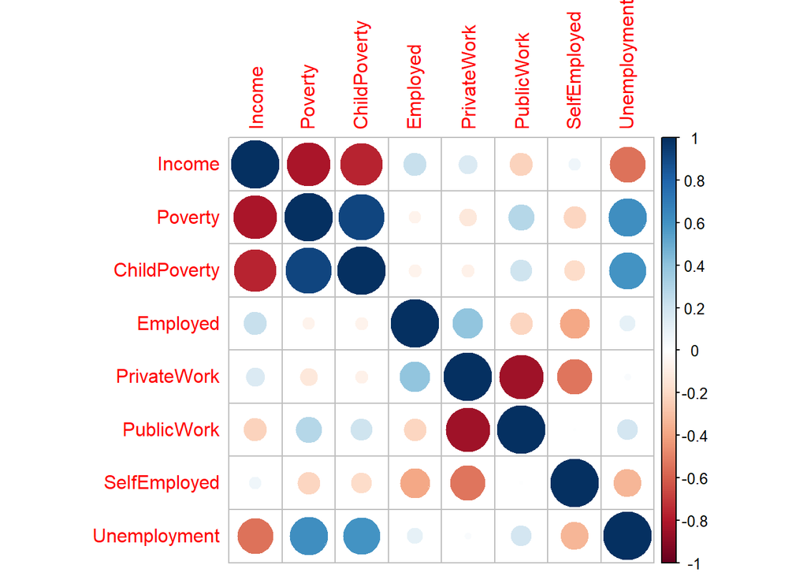

```r
loadPkg("lattice")
loadPkg("ggplot2")
loadPkg("corrplot")




# To subset the data with numerical values only.
data_num2 <- data.frame (subset(Adata9, select = -c(State,County,CensusId,Citizen,Service,Office,Professional, Construction, Production,WorkAtHome, TotalPop, Men, Women, FamilyWork)))


matrix2 = cor(data_num2) # get the correlation matrix between all numerical variables.
head(matrix2)
matrix2

corrplot(matrix2)
```

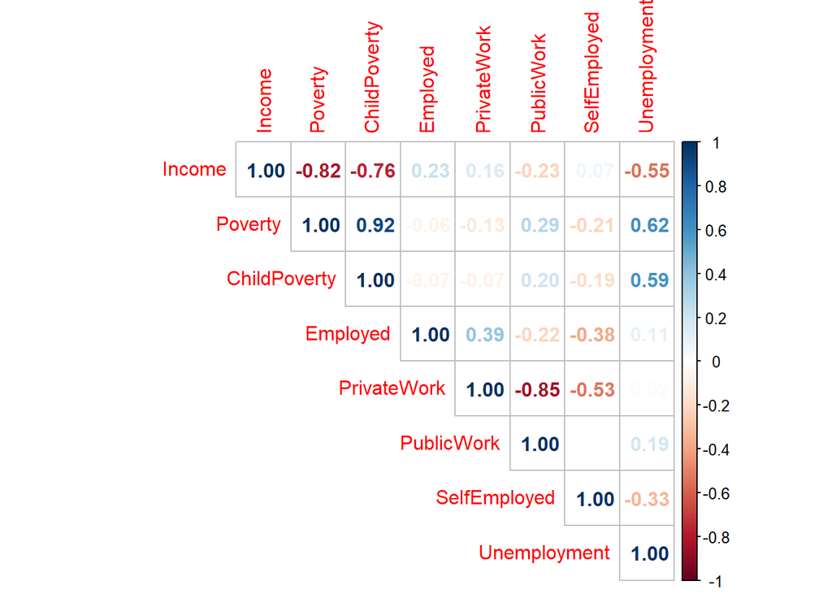

[output not shown]

```r
corrplot(matrix2, method = "number", type="upper")
```

**By using numerical variables only, we will build a linear model with 1 independent variable to predict the income.**

We Choose a variable with strong correlation coefficient and here is our result:

2- The p-value is less than 0.05 which means the Unemployment is statistically significant predictor of income.

3- The coefficient estimate value is equals to -1575.3 which means that there is 1575.3 decrease in the income when the Unemployment changed by 1.

4- Coefficient-Standard Error= 52.9, so we can say that the income can vary by 52.9

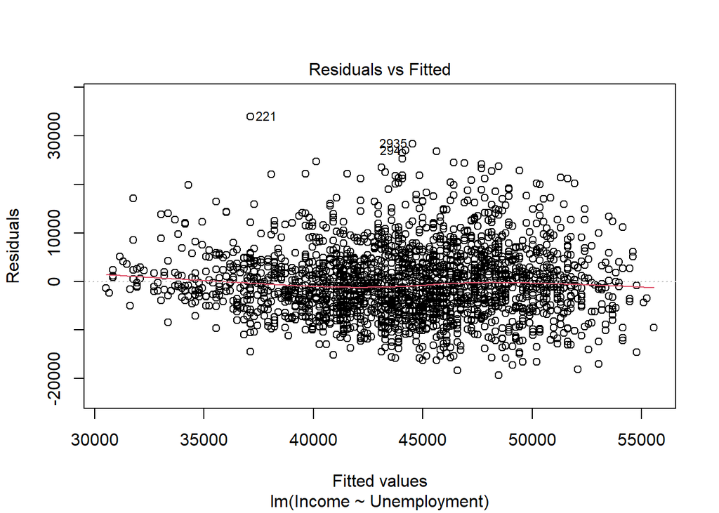

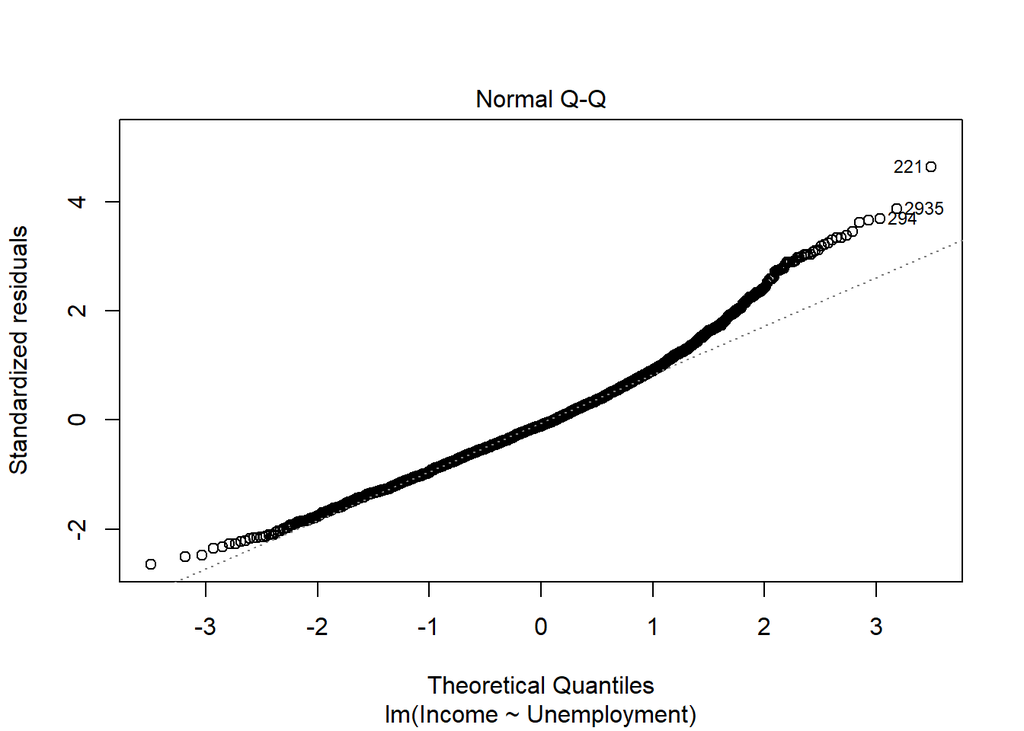

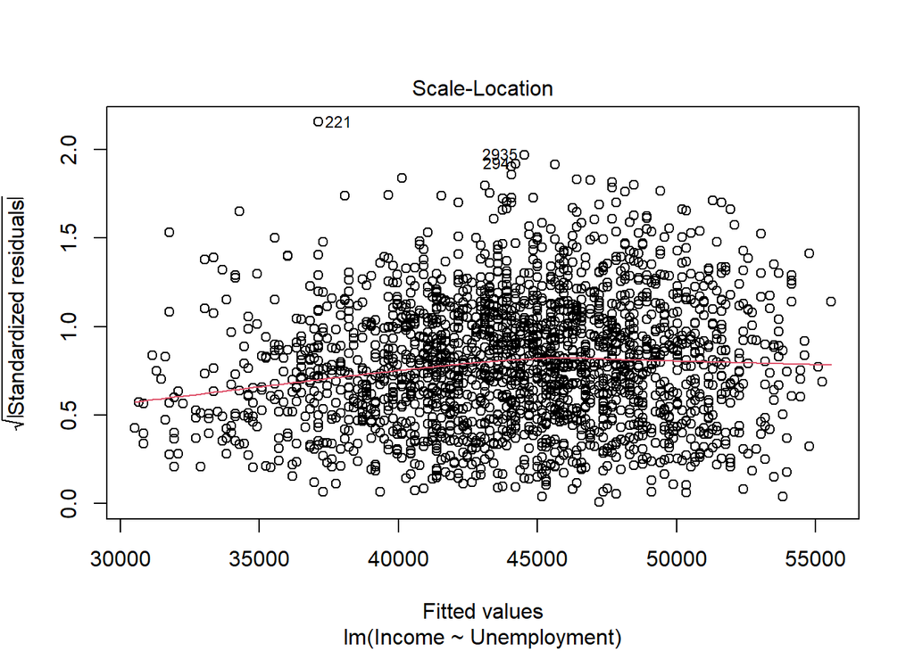

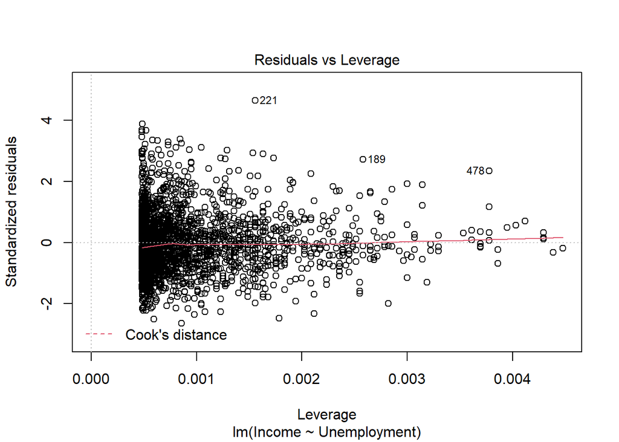

```
##
##  Pearson's product-moment correlation
##
## data:  Adata9$Unemployment and Adata9$Income
## t = -30, df = 2071, p-value <2e-16
## alternative hypothesis: true correlation is not equal to 0
## 95 percent confidence interval:
##  -0.577 -0.516
## sample estimates:
##    cor
## -0.547
##
##
## Call:
## lm(formula = Income ~ Unemployment, data = Adata9)
##
## Residuals:
##    Min     1Q Median     3Q    Max
## -19356  -4801   -770   3982  33950
##
## Coefficients:
##              Estimate Std. Error t value Pr(>|t|)
## (Intercept)   56345.3      436.9   129.0   <2e-16 ***
## Unemployment  -1575.3       52.9   -29.8   <2e-16 ***
## ---
## Signif. codes:  0 '***' 0.001 '**' 0.01 '*' 0.05 '.' 0.1 ' ' 1
##
## Residual standard error: 7310 on 2071 degrees of freedom
## Multiple R-squared:   0.3,   Adjusted R-squared:  0.299
## F-statistic:  886 on 1 and 2071 DF,  p-value: <2e-16
```

Model : Income ~ Unemployment

|  | Estimate | Std. Error | t value | Pr(>\|t\|) |
| --- | --- | --- | --- | --- |
| (Intercept) | 56345 | 436.9 | 129.0 | 0 |
| Unemployment | -1575 | 52.9 | -29.8 | 0 |

```r
cor.test(Adata9$Unemployment, Adata9$Income) -> cortest_1
cortest_1

fit_1 <- lm(Income ~ Unemployment, data = Adata9)
summary(fit_1)

xkabledply(fit_1, title = paste("Model :", format(formula(fit_1)) ) )

plot(fit_1)
```

**Next, we will add a second variable to the model.**

We Choose a variable with stronger correlation coefficient and here is our result:

1- Multiple R-squared value is equal to: 0.675 which means: 67.5% of the variability in income is explained by the variability in unemployment and poverty.

2- The p-values of unemployment and poverty are less than 0.05 which means that they are statistically significant predictor of income.

3- The coefficient estimate value of the unemployment is equals to -186.2 which means that there is 186.2 decrease in the income when the unemployment changed by 1.

4- The coefficient estimate value of the poverty is equals to -1220.5 which means that there is 1220.5 decrease in the income when the poverty changed by 1.

5- The Coefficient-Standard Error for the unemployment = 45.9, so we can say that the income can vary by 45.9

6- The Coefficient-Standard Error for the poverty = 25, so we can say that the income can vary by 25

```r
fit_2 <- lm(Income ~ Unemployment+Poverty, data = Adata9)
summary(fit_2)




xkabledply(fit_2, title = paste("Model :", format(formula(fit_2)) ) )
xkablevif(fit_2)
```

```
##
## Call:
## lm(formula = Income ~ Unemployment + Poverty, data = Adata9)
##
## Residuals:
##    Min     1Q Median     3Q    Max
## -16110  -3200   -577   2694  23719
##
## Coefficients:
##              Estimate Std. Error t value Pr(>|t|)
## (Intercept)   66354.2      361.3  183.64  < 2e-16 ***
## Unemployment   -186.2       45.9   -4.06  5.2e-05 ***
## Poverty       -1220.5       25.0  -48.88  < 2e-16 ***
## ---
## Signif. codes:  0 '***' 0.001 '**' 0.01 '*' 0.05 '.' 0.1 ' ' 1
##
## Residual standard error: 4980 on 2070 degrees of freedom
## Multiple R-squared:  0.675,  Adjusted R-squared:  0.675
## F-statistic: 2.15e+03 on 2 and 2070 DF,  p-value: <2e-16
```

Model : Income ~ Unemployment + Poverty

|  | Estimate | Std. Error | t value | Pr(>\|t\|) |
| --- | --- | --- | --- | --- |
| (Intercept) | 66354 | 361.3 | 183.64 | 0e+00 |
| Unemployment | -186 | 45.9 | -4.06 | 1e-04 |
| Poverty | -1220 | 25.0 | -48.88 | 0e+00 |

VIFs of the model

| Poverty | Unemployment |
| --- | --- |
| 1.62 | 1.62 |

**We will try one more time to add a third variable in our model.**

```r
fit_3 <- lm(Income ~ Unemployment+Poverty+ChildPoverty, data = Adata9)
summary(fit_3)



xkabledply(fit_3, title = paste("Model :", format(formula(fit_3)) ) )
xkablevif(fit_3)
```

```
##
## Call:
## lm(formula = Income ~ Unemployment + Poverty + ChildPoverty,
##     data = Adata9)
##
## Residuals:
##    Min     1Q Median     3Q    Max
## -16480  -3216   -520   2699  23805
##
## Coefficients:
##              Estimate Std. Error t value Pr(>|t|)
## (Intercept)   66284.8      363.8  182.21  < 2e-16 ***
## Unemployment   -180.2       46.1   -3.91  9.4e-05 ***
## Poverty       -1150.1       50.5  -22.77  < 2e-16 ***
## ChildPoverty    -48.9       30.5   -1.60     0.11
## ---
## Signif. codes:  0 '***' 0.001 '**' 0.01 '*' 0.05 '.' 0.1 ' ' 1
##
## Residual standard error: 4980 on 2069 degrees of freedom
## Multiple R-squared:  0.675,  Adjusted R-squared:  0.675
## F-statistic: 1.43e+03 on 3 and 2069 DF,  p-value: <2e-16
```

Model : Income ~ Unemployment + Poverty + ChildPoverty

|  | Estimate | Std. Error | t value | Pr(>\|t\|) |
| --- | --- | --- | --- | --- |
| (Intercept) | 66284.8 | 363.8 | 182.21 | 0.0000 |
| Unemployment | -180.2 | 46.1 | -3.91 | 0.0001 |
| Poverty | -1150.1 | 50.5 | -22.77 | 0.0000 |
| ChildPoverty | -48.9 | 30.5 | -1.60 | 0.1092 |

VIFs of the model

[output not shown]

**Confidence intervals of the coefficients.**

```r
confint(fit_3)
```

```
##              2.5 %  97.5 %
## (Intercept)  65571 66998.2
## Unemployment  -271   -89.9
## Poverty      -1249 -1051.1
## ChildPoverty  -109    11.0
```

**We used ANOVA to compare the three different models we found.**

The p-value for the second model < 0.05 , which means that the second model is significantly different than the first model.

The p-value for the third model is not that significant.

As a result, the second model is the best among all.

```r
anovaRes_1 <- anova(fit_1,fit_2,fit_3)
anovaRes_1
str(anovaRes_1)

xkabledply(anovaRes_1, title = "ANOVA comparison between the models") # to show it in a table
```

```
## Analysis of Variance Table
##
## Model 1: Income ~ Unemployment
## Model 2: Income ~ Unemployment + Poverty
## Model 3: Income ~ Unemployment + Poverty + ChildPoverty
##   Res.Df      RSS Df Sum of Sq       F Pr(>F)
## 1   2071 1.11e+11
## 2   2070 5.13e+10  1  5.92e+10 2391.49 <2e-16 ***
## 3   2069 5.13e+10  1  6.36e+07    2.57   0.11
## ---
## Signif. codes:  0 '***' 0.001 '**' 0.01 '*' 0.05 '.' 0.1 ' ' 1
## Classes 'anova' and 'data.frame':    3 obs. of  6 variables:
##  $ Res.Df   : num  2071 2070 2069
##  $ RSS      : num  1.11e+11 5.13e+10 5.13e+10
##  $ Df       : num  NA 1 1
##  $ Sum of Sq: num  NA 5.92e+10 6.36e+07
##  $ F        : num  NA 2391.49 2.57
##  $ Pr(>F)   : num  NA 0 0.109
##  - attr(*, "heading")= chr [1:2] "Analysis of Variance Table\n" "Model 1: Income ~ Unemployment\nModel 2: Income ~ Unemployment + Poverty\nModel 3: Income ~ Unemployment + Pove"| __truncated__
```

ANOVA comparison between the models

| Res.Df | RSS | Df | Sum of Sq | F | Pr(>F) |
| --- | --- | --- | --- | --- | --- |
| 2071 | 1.11e+11 | NA | NA | NA | NA |
| 2070 | 5.13e+10 | 1 | 5.92e+10 | 2391.49 | 0.000 |
| 2069 | 5.13e+10 | 1 | 6.36e+07 | 2.57 | 0.109 |

### Chapter 5: Unemployment Prediction Test.

1. Does a relationship exist between ‘child poverty’ and ‘unemployment’?

First, let’s start to get a general idea of how ChildPoverty relates to all the factors by looking at the correlation matrix between ‘ChildPoverty’ and the other variables. 1. Correlation 2.EDA–Exploratory Data Analysis (EDA) is the process of analyzing and visualizing the data to get a better understanding of the data and glean insight from it. There are various steps involved when doing EDA but the following are the common steps that a data analyst can take when performing EDA: a.Import the data b.Clean the data c.Process the data d.Visualize the data 3.Regression—–Regression analysis is a group of statistical processes used in R programming and statistics to determine the relationship between dataset variables. Generally, regression analysis is used to determine the relationship between the dependent and independent variables of the dataset. 4.Decision Tree plotting

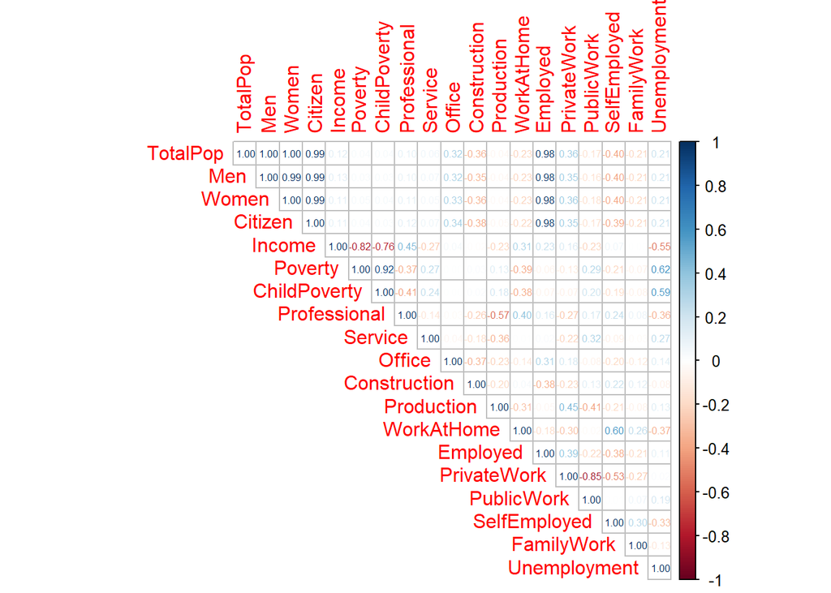

```r
library(corrplot)
subset1<-subset(Adata9,select = -c(CensusId,State,County))
crr<-cor(subset1)
corrplot(crr,method = 'number',type = 'upper',number.font = 1, number.cex = 0.5)
```

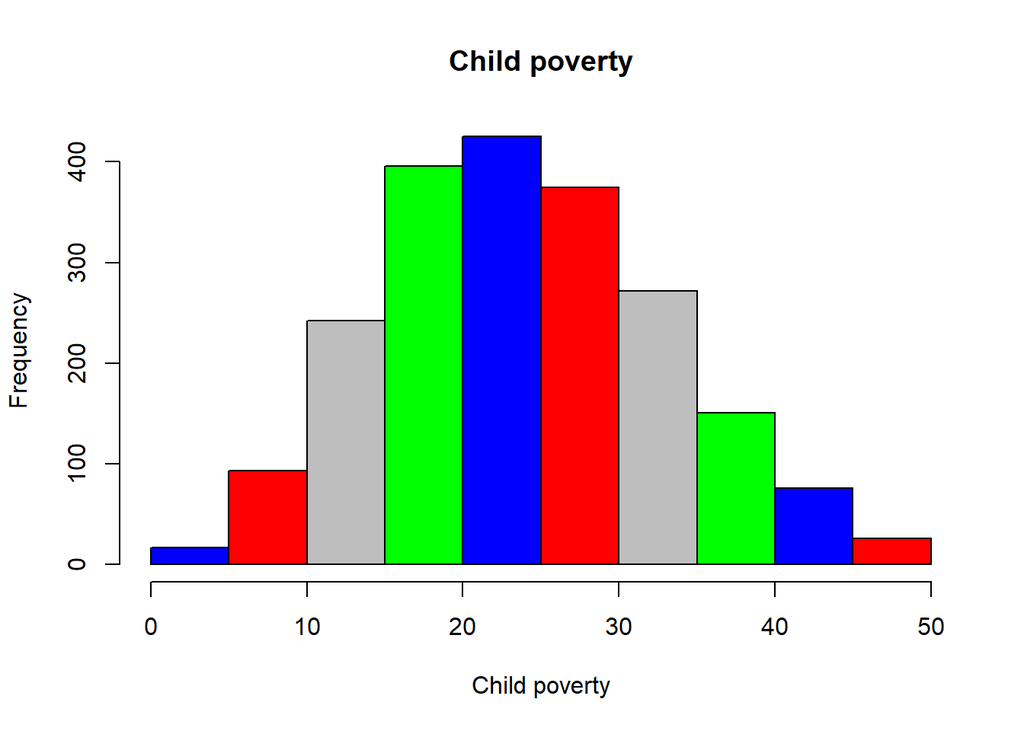

```r
# EDA on child poverty
library(ggplot2)
library(ISLR2)
data(package="ISLR2")
require(tree)
Adata10 <- Adata9
names(Adata10)

#histogram of child Poverty and unemployement

hist(Adata10$ChildPoverty, main="Child poverty", xlab = "Child poverty",col = c("blue", "red", "gray", "green"))
```

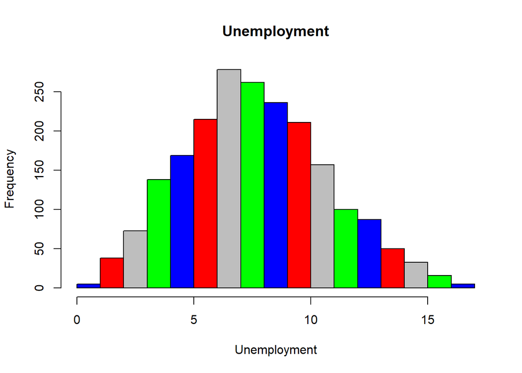

```r
hist(Adata10$Unemployment, main="Unemployment",xlab = "Unemployment" ,col = c("blue", "red", "gray", "green"))
```

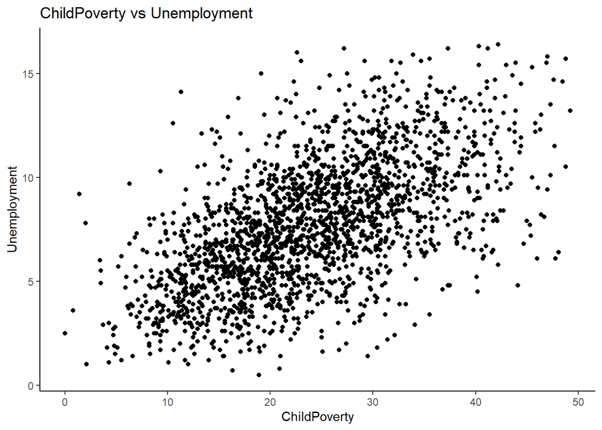

```r
# regression and scatter plot of child poverty and Selected features.

ggplt <- ggplot(Adata9,aes(x=ChildPoverty,y=Unemployment))+
         geom_point()+labs(title = "ChildPoverty vs Unemployment")+labs(x="ChildPoverty", y="Unemployment" )+
         theme_classic()

ggplt
```

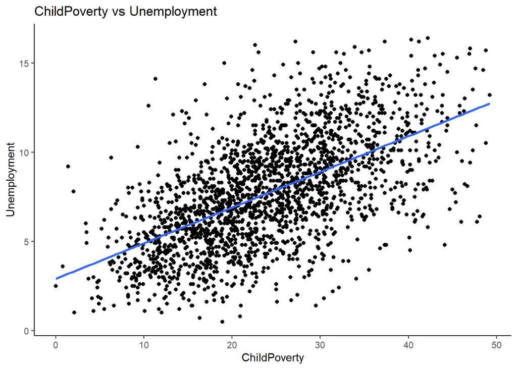

```r
# Plotting a single Regression Line
ggplt+geom_smooth(method=lm,se=FALSE,fullrange=TRUE)
```

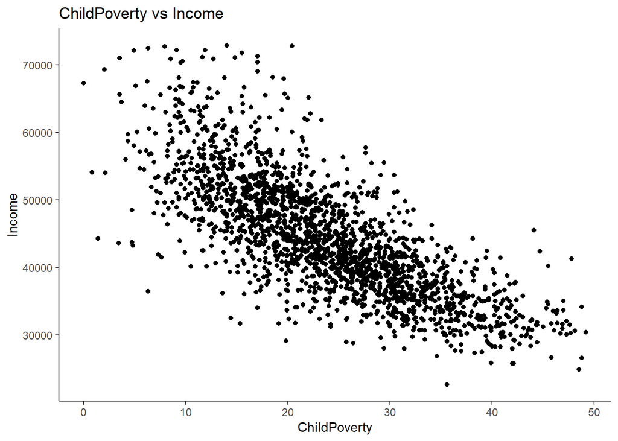

```r
ggplt1 <- ggplot(Adata9,aes(x=ChildPoverty,y=Income))+
         geom_point()+labs(title = "ChildPoverty vs Income")+labs(x="ChildPoverty", y="Income" )+
         theme_classic()

ggplt1
```

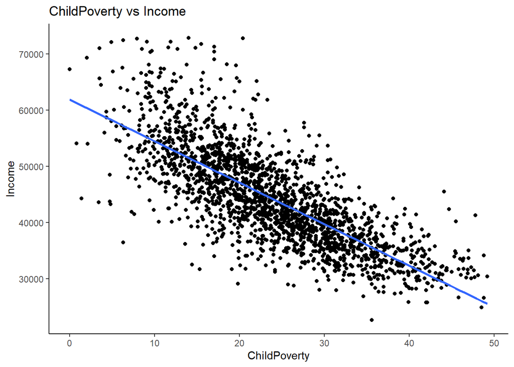

```r
# Plotting a single Regression Line
ggplt1+geom_smooth(method=lm,se=FALSE,fullrange=TRUE)
```

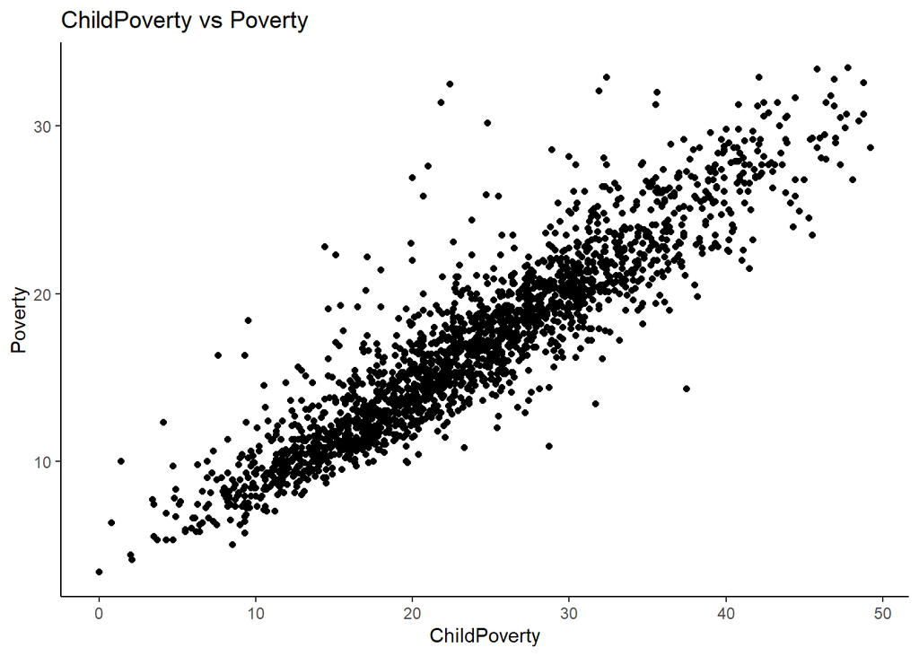

```r
ggplt2 <- ggplot(Adata9,aes(x=ChildPoverty,y=Poverty))+
         geom_point()+labs(title = "ChildPoverty vs Poverty")+labs(x="ChildPoverty", y="Poverty" )+
         theme_classic()

ggplt2
```

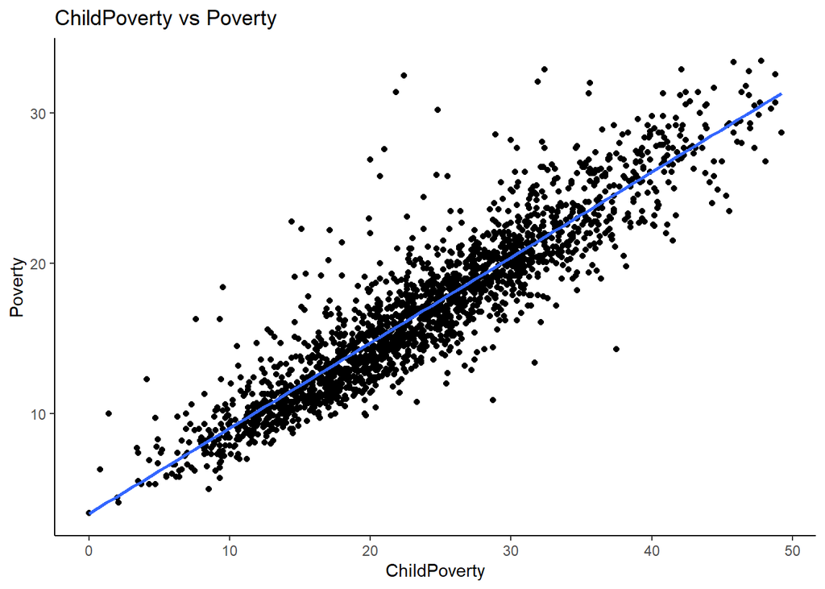

```r
# Plotting a single Regression Line
ggplt2+geom_smooth(method=lm,se=FALSE,fullrange=TRUE)
```

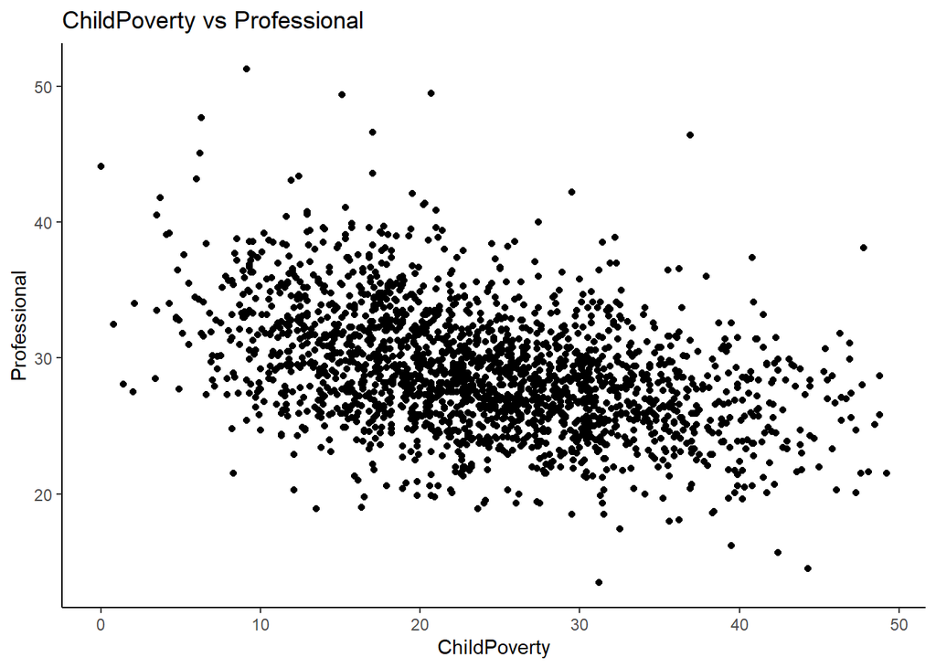

```r
ggplt3 <- ggplot(Adata9,aes(x=ChildPoverty,y=Professional))+
         geom_point()+labs(title = "ChildPoverty vs Professional")+labs(x="ChildPoverty", y="Professional" )+
         theme_classic()

ggplt3
```

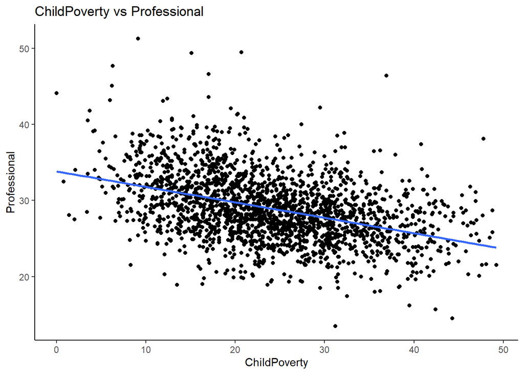

```r
# Plotting a single Regression Line
ggplt3+geom_smooth(method=lm,se=FALSE,fullrange=TRUE)
```

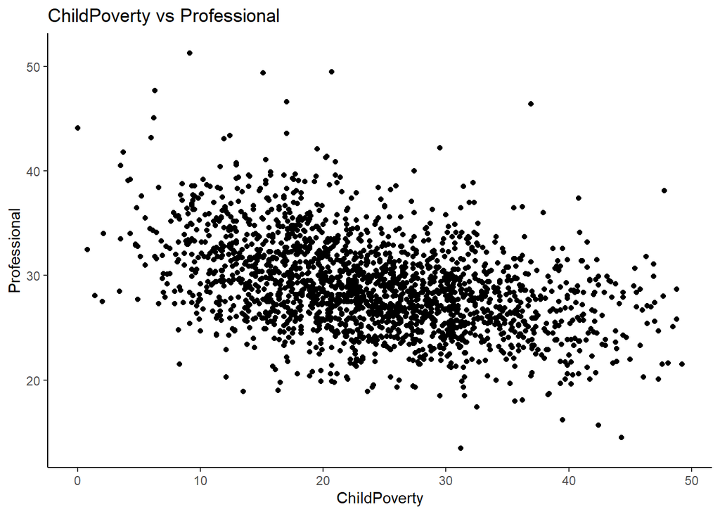

```r
ggplt3 <- ggplot(Adata9,aes(x=ChildPoverty,y=Professional))+
         geom_point()+labs(title = "ChildPoverty vs Professional")+labs(x="ChildPoverty", y="Professional" )+
         theme_classic()

ggplt3
```

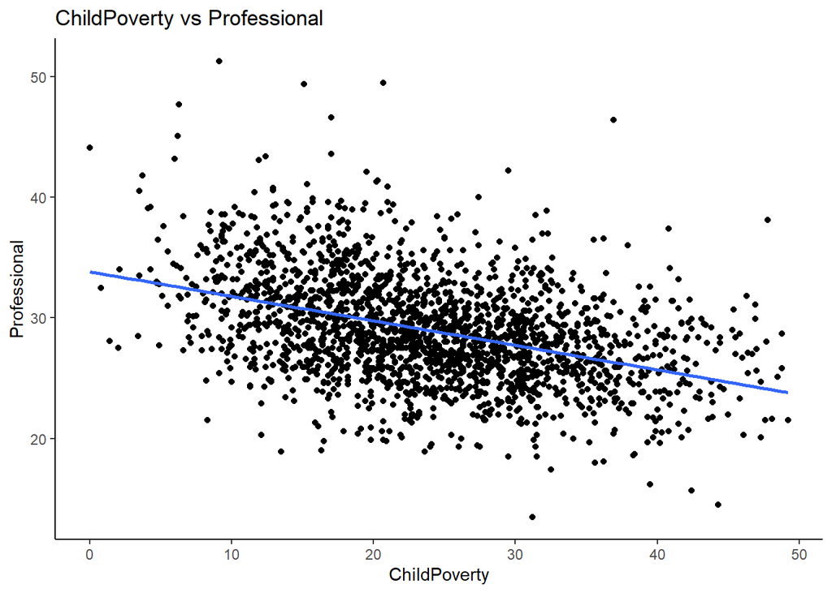

```r
# Plotting a single Regression Line
ggplt3+geom_smooth(method=lm,se=FALSE,fullrange=TRUE)
```

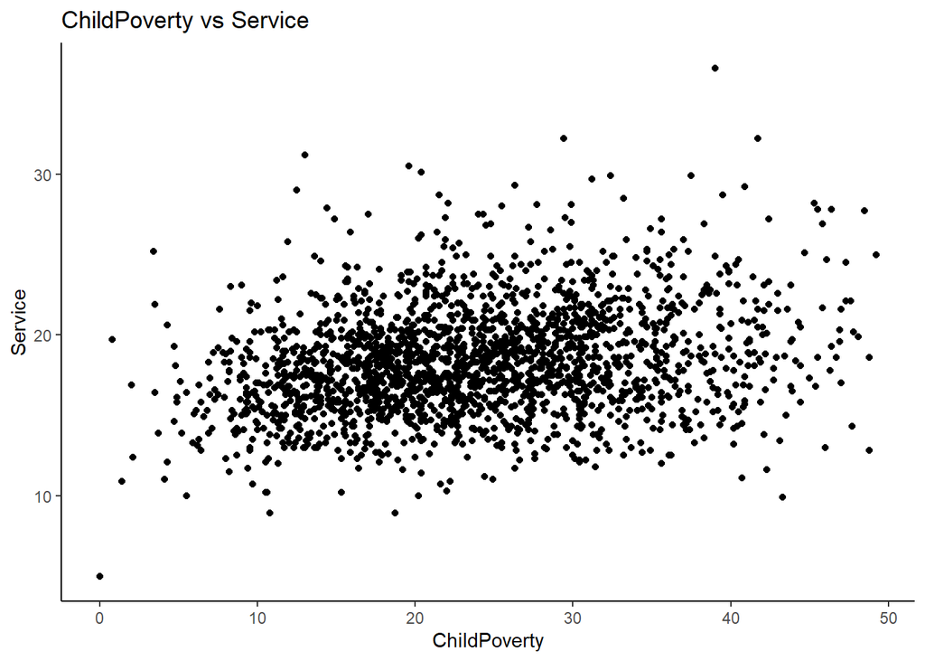

```r
ggplt4 <- ggplot(Adata9,aes(x=ChildPoverty,y=Service))+
         geom_point()+labs(title = "ChildPoverty vs Service")+labs(x="ChildPoverty", y="Service" )+
         theme_classic()

ggplt4
```

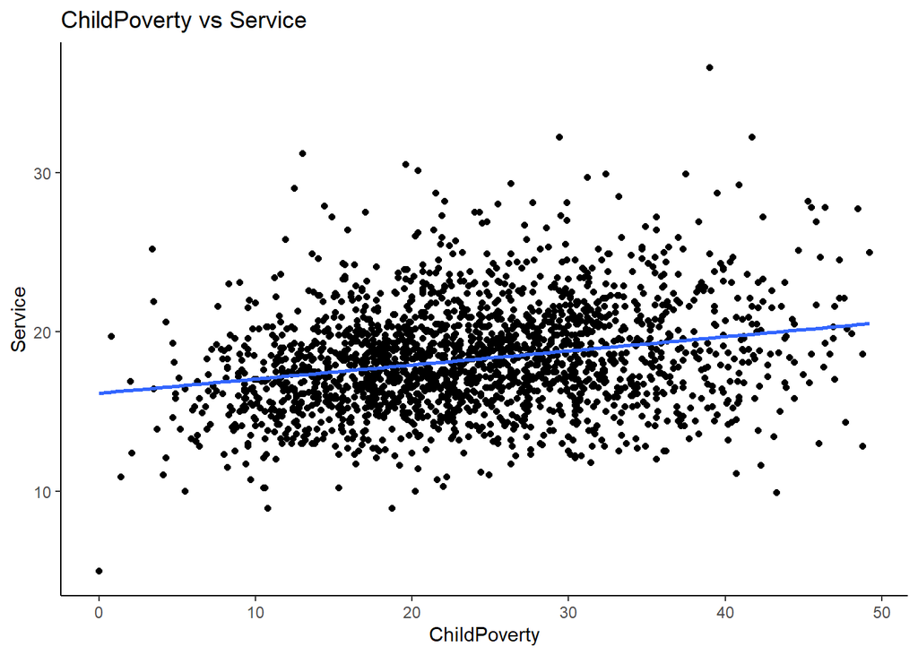

```r
# Plotting a single Regression Line
ggplt4+geom_smooth(method=lm,se=FALSE,fullrange=TRUE)
```

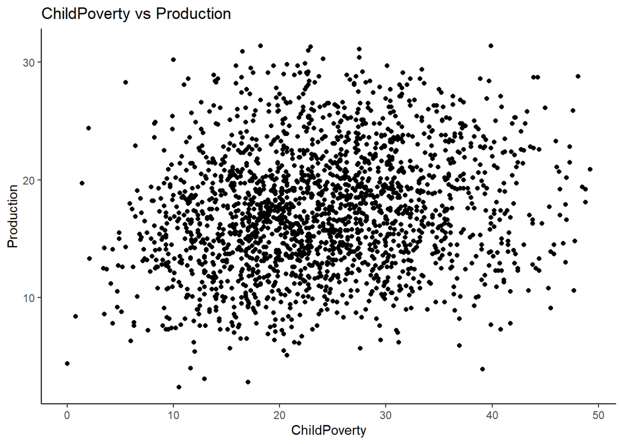

```r
ggplt5 <- ggplot(Adata9,aes(x=ChildPoverty,y=Production))+
         geom_point()+labs(title = "ChildPoverty vs Production")+labs(x="ChildPoverty", y="Production" )+
         theme_classic()

ggplt5
```

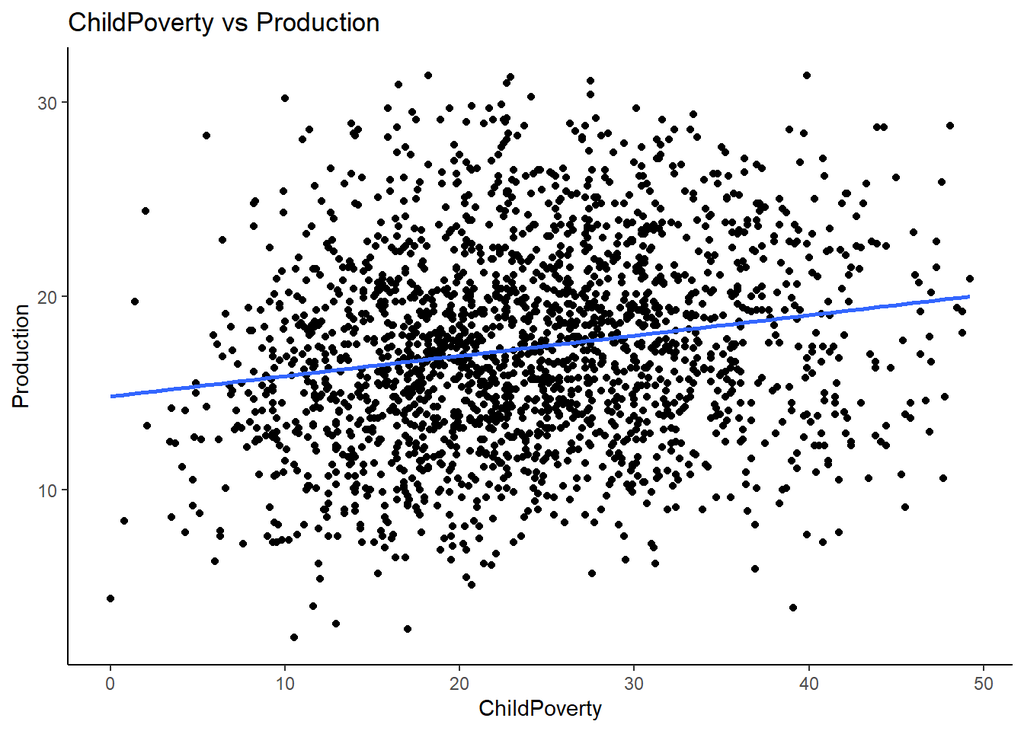

```r
# Plotting a single Regression Line
ggplt5+geom_smooth(method=lm,se=FALSE,fullrange=TRUE)
```

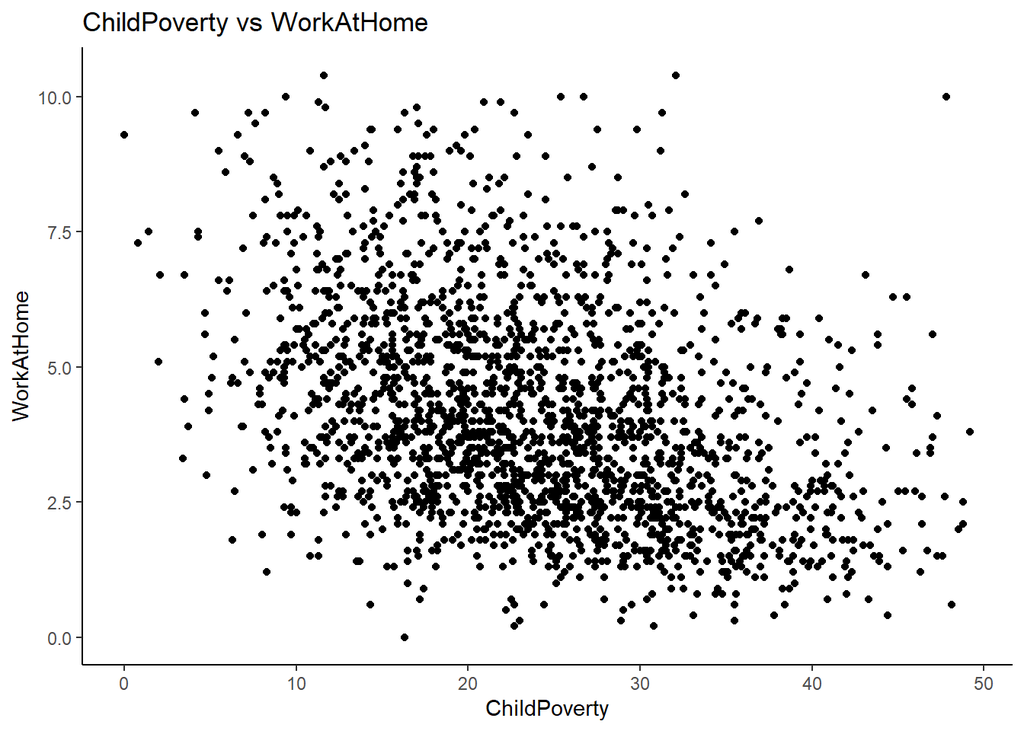

```r
ggplt6 <- ggplot(Adata9,aes(x=ChildPoverty,y=WorkAtHome))+
         geom_point()+labs(title = "ChildPoverty vs WorkAtHome")+labs(x="ChildPoverty", y="WorkAtHome" )+
         theme_classic()

ggplt6
```

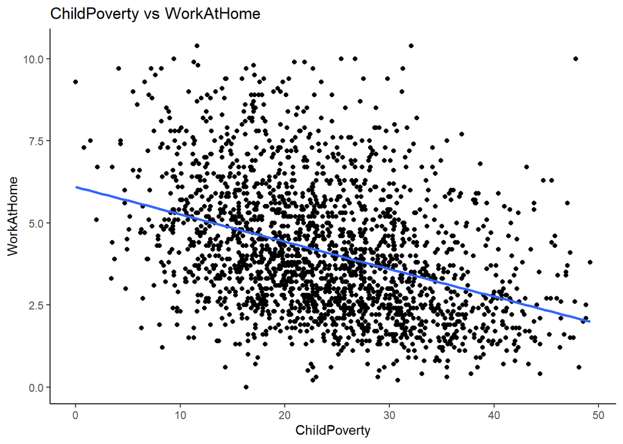

```r
# Plotting a single Regression Line
ggplt6+geom_smooth(method=lm,se=FALSE,fullrange=TRUE)
```

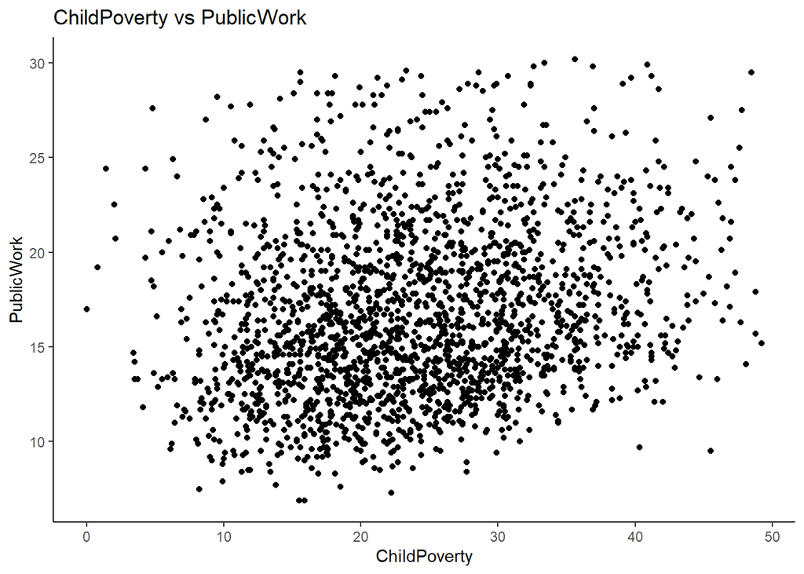

```r
ggplt7 <- ggplot(Adata9,aes(x=ChildPoverty,y=PublicWork))+
         geom_point()+labs(title = "ChildPoverty vs PublicWork")+labs(x="ChildPoverty", y="PublicWork" )+
         theme_classic()

ggplt7
```

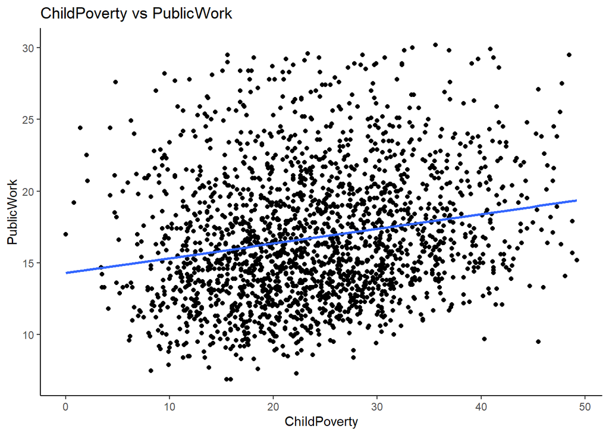

```r
# Plotting a single Regression Line
ggplt7+geom_smooth(method=lm,se=FALSE,fullrange=TRUE)
```

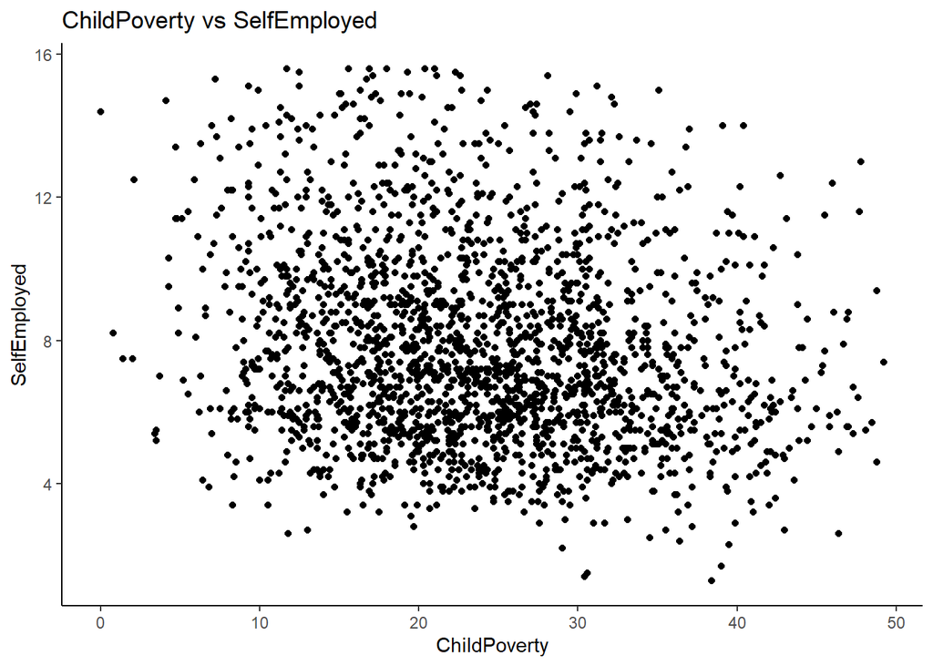

```r
ggplt8 <- ggplot(Adata9,aes(x=ChildPoverty,y=SelfEmployed))+
         geom_point()+labs(title = "ChildPoverty vs SelfEmployed")+labs(x="ChildPoverty", y="SelfEmployed" )+
         theme_classic()

ggplt8
```

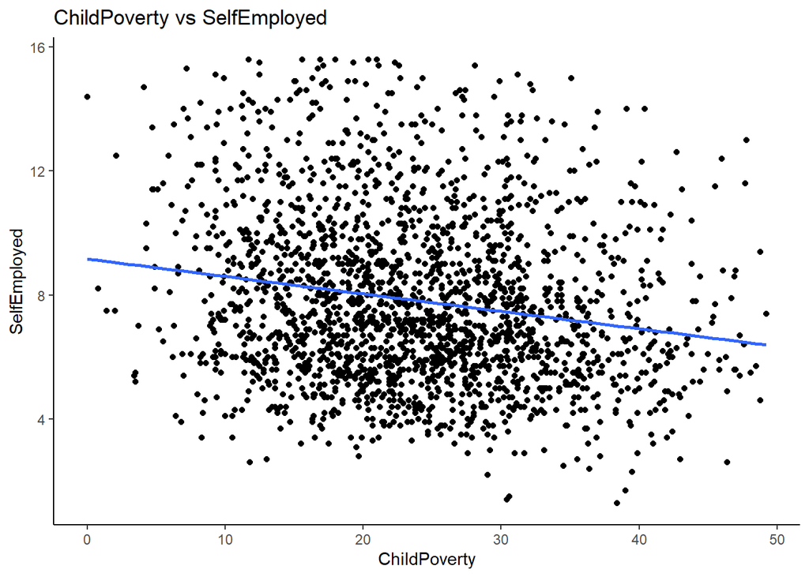

```r
# Plotting a single Regression Line
ggplt8+geom_smooth(method=lm,se=FALSE,fullrange=TRUE)
```